# 1: Relação entre SAT e GPA

```r
data = read_csv(here::here("data/sat-gpa.csv"),
                 col_types = "nndd")

glimpse(data)
```

```
Rows: 105
Columns: 4
$ math_SAT <dbl> 643, 558, 583, 685, 592, 562, 573, 559, 552, 617, 684, 568, 604, 619, 642, 683, 703, 712, 564, 557, 591, 599, 607, 619, 700, 718,…
$ verb_SAT <dbl> 589, 512, 503, 602, 538, 486, 548, 536, 583, 591, 649, 592, 582, 624, 619, 642, 684, 652, 501, 549, 584, 562, 619, 558, 721, 732,…
$ comp_GPA <dbl> 3.76, 2.87, 2.54, 3.83, 3.29, 2.64, 2.86, 2.03, 2.81, 3.41, 3.61, 2.48, 3.21, 3.52, 3.41, 3.52, 3.84, 3.64, 2.14, 2.21, 3.17, 3.0…
$ univ_GPA <dbl> 3.52, 2.91, 2.40, 3.47, 3.47, 2.37, 2.40, 2.24, 3.02, 3.32, 3.59, 2.54, 3.19, 3.71, 3.58, 3.40, 3.73, 3.49, 2.25, 2.37, 3.29, 3.1…
```

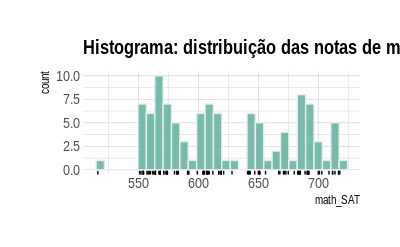

```r
data %>%
  ggplot( aes(x=math_SAT)) +
    geom_histogram( binwidth=7, fill="#69b3a2", color="#e9ecef", alpha=0.9) +
    geom_rug() +
    ggtitle("Histograma: distribuição das notas de matemática do SAT") +
    theme_ipsum() +
    theme(
      plot.title = element_text(size=15)
    )
```

Segundo o histograma da distribuição das notas de matemática do SAT, podemos observar uma grande variabilidade. Esperava encontrar uma distribuição normal ou assimétrica; entretanto, nos deparamos com uma distribuição multimodal, com picos por volta 570 e 680, e com dados variando em sua maior parte de 550 a 718.

```r
data %>%
  summarise(
    min = min(math_SAT),
    max = max(math_SAT),
    mean = mean(math_SAT),
    median = median(math_SAT),
    quantile25 = quantile(math_SAT, .25),
    quantile75 = quantile(math_SAT, .75),
    n = n()
  )
```

| min | max | mean | median | quantile25 | quantile75 | n |
| --- | --- | --- | --- | --- | --- | --- |
| 516 | 718 | 623.0762 | 612 | 573 | 675 | 105 |

Através da tabela acima, podemos observar que 50% dos dados pertencem ao intervalo 573 a 675, que a média e a mediana são próximas, e que os valores mínimo e máximo são 516 e 718, respectivamente. O valor 516 parece ser um valor extremo na distribuição. Não existem caudas perceptíveis na distribuição.

No histograma abaixo, iremos analisar a distribuição das notas de expressão verbal do SAT. É possível observar que parece existir uma normalidade dos dados e que estão distribuídos em todo o intervalo.

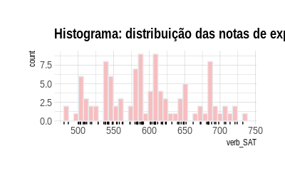

```r
data %>%
  ggplot( aes(x=verb_SAT)) +
    geom_histogram( binwidth=7, fill="#F6B7B9", color="#e9ecef", alpha=0.9) +
    geom_rug() +
    ggtitle("Histograma: distribuição das notas de expressão verbal do SAT") +
    theme_ipsum() +
    theme(
      plot.title = element_text(size=15)
    )
```

```r
data %>%
  summarise(
    min = min(verb_SAT),
    max = max(verb_SAT),
    mean = mean(verb_SAT),
    median = median(verb_SAT),
    quantile25 = quantile(verb_SAT, .25),
    quantile75 = quantile(verb_SAT, .75),
    n = n()
  )
```

| min | max | mean | median | quantile25 | quantile75 | n |
| --- | --- | --- | --- | --- | --- | --- |
| 480 | 732 | 598.6 | 591 | 548 | 645 | 105 |

Através da tabela acima, podemos observar que 50% dos dados pertencem ao intervalo 548 a 645, que a média e a mediana são próximas, e que os valores mínimo e máximo são 480 e 732, respectivamente. As notas de expressão verbal parecem ter uma dispersão maior em relação às notas de matemática. Não existem caudas perceptíveis na distribuição.

```r
pivot_data = data %>%
  select(math_SAT, verb_SAT) %>%
  pivot_longer(c(math_SAT, verb_SAT))
```

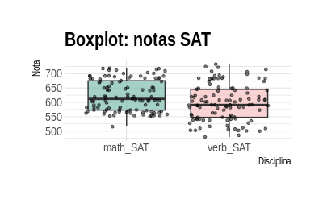

```r
pivot_data %>%
  ggplot(aes(x=name, y=value, fill=name)) +
  geom_boxplot(alpha=0.6) +
  scale_fill_manual(values=c("#69b3a2", "#F6B7B9")) +
  geom_jitter(size = 1, alpha = .5, col="black") +
  theme_ipsum() +
  theme(legend.position = "none") +
  labs(
    title="Boxplot: notas SAT",
    x ="Disciplina", y = "Nota"
  )
```

Na visualização de boxplot acima, podemos observar com maior clareza que a disciplina expressão verbal (verb_SAT) possui maior variabilidade do que a disciplina matemática (math_SAT), que na disciplina matemática os dados estão concentrados ligeiramente mais na porção inferior enquanto que na outra disciplina está mais próxima do centro.

Agora, iremos utilizar o gráfico de dispersão para tentar identificar visualmente se existe alguma correlação entre as notas das duas disciplinas.

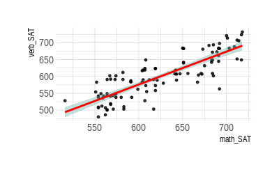

```r
# basic scatterplot
data %>%
ggplot(aes(x=math_SAT, y=verb_SAT)) +
  geom_point(size = 1, alpha = .8) +
  geom_smooth(method=lm , color="red", fill="#69b3a2", se=TRUE) +
  theme_ipsum()
```

Neste gráfico de dispersão acima, podemos perceber que parece existir uma correlação linear positiva entre as notas; ou seja, conforme uma aumenta, a outra aumenta também. Não significa que exista uma relação causal entre ambas as variáveis.

Através dos testes de normalidade abaixo (Shapiro-Wilk), verificamos que ambas as distribuições não são normais.

```r
cat("Teste de normalidade das notas de matemática: ", (shapiro.test(data$math_SAT)$p.value > 0.05))
```

```
Teste de normalidade das notas de matemática:  FALSE
```

```r
cat("\n")
```

```r
cat("Teste de normalidade das notas de expressão verbal: ", (shapiro.test(data$verb_SAT)$p.value > 0.05))
```

```
Teste de normalidade das notas de expressão verbal:  FALSE
```

A seguir, realizaremos um teste de correlação linear entre as notas das disciplinas matemática e expressão verbal.

```r
cor.test(data$math_SAT, data$verb_SAT, method = "pearson")
```

```
    Pearson's product-moment correlation

data:  data$math_SAT and data$verb_SAT
t = 15.415, df = 103, p-value < 2.2e-16
alternative hypothesis: true correlation is not equal to 0
95 percent confidence interval:
 0.7662218 0.8851880
sample estimates:
      cor
0.8352272
```

Pelo resultado, podemos confirmar que existe uma correlação linear positiva forte (0,76 a 0,88) na amostra testada, o que poderia indicar que também haja correlação para os dados da população.

Na próxima etapa, iremos analisar a distribuição das notas de computação no sistema GPA e depois comparar a comentar como é a correlação entre o desempenho dos alunos em cada uma das disciplinas e seu desempenho nas matérias de computação do curso.

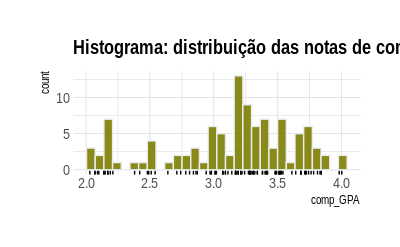

```r
data %>%
  ggplot( aes(x=comp_GPA)) +
    geom_histogram( fill="#7D7D02", color="#e9ecef", alpha=0.9) +
    geom_rug() +
    ggtitle("Histograma: distribuição das notas de computação do GPA") +
    theme_ipsum() +
    theme(
      plot.title = element_text(size=15)
    )
```

A partir do histograma das notas de computação no sistema GPA, podemos observar que parece existir duas concentrações: uma que vai de 2,0 a aprox. 2,5 e outra de 2,5 a 4,0. Cada qual com picos próximos dos valores 2,25 e 3,25, respectivamente. A escala de notas varia de 0 a 4.0 e os dados da amostra mostram que as notas variam de 2 a 4. Em toda a amostra, podemos perceber que há uma assimetria com maior concentração à direita dos dados entre 3,25 a 3,5.

Através dos dados da tabela abaixo, podemos observar que 50% dos dados da amostra pertencem ao intervalo de notas de 2,87 a 3,49. A menor e maior notas foram 2,03 e 4,0, respectivamente. Temos a média e a mediana sendo próximas uma da outra e que seus valores estão mais próximas do lado direito da escala de 0 a 4, confirmando a observação sobre a concentração à direita.

```r
data %>%
  summarise(
    min = min(comp_GPA),
    max = max(comp_GPA),
    mean = mean(comp_GPA),
    median = median(comp_GPA),
    quantile25 = quantile(comp_GPA, .25),
    quantile75 = quantile(comp_GPA, .75),
    n = n()
  )
```

| min | max | mean | median | quantile25 | quantile75 | n |
| --- | --- | --- | --- | --- | --- | --- |
| 2.03 | 4 | 3.128 | 3.21 | 2.87 | 3.49 | 105 |

Iremos agora mostrar uma visualização de boxplot para tentarmos identificar mais algumas características da distribuição.

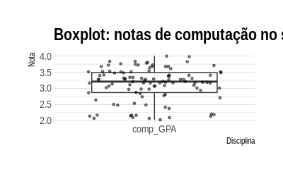

```r
data %>%
  ggplot(aes(x="comp_GPA", y=comp_GPA)) +
  geom_boxplot(alpha=0.6) +
  scale_fill_manual(values=c("#69b3a2", "#F6B7B9")) +
  geom_jitter(size = 1, alpha = .5, col="black") +
  theme_ipsum() +
  theme(legend.position = "none") +
  labs(
    title="Boxplot: notas de computação no sistema GPA",
    x ="Disciplina", y = "Nota"
  )
```

Com o boxplot, confirmamos as observações anteriores e podemos adicionar através de uma confirmação visual de que há uma maior variabilidade dos dados no intervalo inferior à mediana.